# Cyclistic Capstone Case Study

John Embate

2023-01-06

## Introduction

This case study is part of the Google Data Analytics Professional Certificate requirements. It is based on the fictional company **“Cyclistic”**, which provides bike-sharing services throughout Chicago. The company now has a fleet of *5,824 geotracked bicycles* linked to a network of *692 stations*.

According to the company’s finance analysts, annual members are more profitable than casual riders. As a result, the marketing team at the company must devise a marketing strategy to convert casual riders into annual members. By analyzing and identifying trends in the company’s historical bike trip data, this case study aims to explore/understand how these different types of customers differ from one another, as well as to ask other questions that may provide an idea for the overall marketing strategy to be implemented.

## Ask

This analysis focuses on these 3 main guide questions:

1. *How do annual members and casual riders use Cyclistic bikes differently?*
2. *Why would casual riders buy Cyclistic annual memberships?*
3. *How can Cyclistic use digital media to influence casual riders to become members?*

Main Business Task: **How to convert casual riders to annual members?**

## Prepare

First, let’s load the necessary packages in order to import the dataset we’ll be working with.

```r
library(tidyverse)
```

In this analysis, we will look at the last *12 months* of Cyclistic trip data. The dataset is comprised of dataset from January to December of 2022. The data can be accessed from this [link](https://divvy-tripdata.s3.amazonaws.com/index.html).

```r
jan_2022 <- read.csv("datasets/202201-divvy-tripdata.csv")
feb_2022 <- read.csv("datasets/202202-divvy-tripdata.csv")
mar_2022 <- read.csv("datasets/202203-divvy-tripdata.csv")
apr_2022 <- read.csv("datasets/202204-divvy-tripdata.csv")
may_2022 <- read.csv("datasets/202205-divvy-tripdata.csv")
jun_2022 <- read.csv("datasets/202206-divvy-tripdata.csv")
jul_2022 <- read.csv("datasets/202207-divvy-tripdata.csv")
aug_2022 <- read.csv("datasets/202208-divvy-tripdata.csv")
sep_2022 <- read.csv("datasets/202209-divvy-tripdata.csv")
oct_2022 <- read.csv("datasets/202210-divvy-tripdata.csv")
nov_2022 <- read.csv("datasets/202211-divvy-tripdata.csv")
dec_2022 <- read.csv("datasets/202212-divvy-tripdata.csv")
```

The datasets used in this analysis are downloaded from the link provided above and unzipped in a folder named *“datasets”*. For ease of use, the folder and this Rmd file are both located in the same directory. We renamed the September dataset file to ensure consistency across all files. All changes made to this analysis are made in R in order to properly document the overall process. We did not use Excel or other tools for analysis because the dataset was too large to load, filter, or sort.

## Process

In the following steps, we’ll load any additional packages required for cleaning as well as visualizations.

```r
library(lubridate)
library(dplyr)
library(pryr)
library(skimr)
library(ggplot2)
library(leaflet)
```

Let’s examine the structure of a few of the dataframes we’ve loaded.

```r
# January 2022 dataframe structure:
str(jan_2022)
```

```
'data.frame':   103770 obs. of  13 variables:
 $ ride_id           : chr  "C2F7DD78E82EC875" "A6CF8980A652D272" "BD0F91DFF741C66D" "CBB80ED419105406" ...
 $ rideable_type     : chr  "electric_bike" "electric_bike" "classic_bike" "classic_bike" ...
 $ started_at        : chr  "2022-01-13 11:59:47" "2022-01-10 08:41:56" "2022-01-25 04:53:40" "2022-01-04 00:18:04" ...
 $ ended_at          : chr  "2022-01-13 12:02:44" "2022-01-10 08:46:17" "2022-01-25 04:58:01" "2022-01-04 00:33:00" ...
 $ start_station_name: chr  "Glenwood Ave & Touhy Ave" "Glenwood Ave & Touhy Ave" "Sheffield Ave & Fullerton Ave" "Clark St & Bryn Mawr Ave" ...
 $ start_station_id  : chr  "525" "525" "TA1306000016" "KA1504000151" ...
 $ end_station_name  : chr  "Clark St & Touhy Ave" "Clark St & Touhy Ave" "Greenview Ave & Fullerton Ave" "Paulina St & Montrose Ave" ...
 $ end_station_id    : chr  "RP-007" "RP-007" "TA1307000001" "TA1309000021" ...
 $ start_lat         : num  42 42 41.9 42 41.9 ...
 $ start_lng         : num  -87.7 -87.7 -87.7 -87.7 -87.6 ...
 $ end_lat           : num  42 42 41.9 42 41.9 ...
 $ end_lng           : num  -87.7 -87.7 -87.7 -87.7 -87.6 ...
 $ member_casual     : chr  "casual" "casual" "member" "casual" ...
```

```r
# December 2022 dataframe structure:
str(dec_2022)
```

```
'data.frame':   181806 obs. of  13 variables:
 $ ride_id           : chr  "65DBD2F447EC51C2" "0C201AA7EA0EA1AD" "E0B148CCB358A49D" "54C5775D2B7C9188" ...
 $ rideable_type     : chr  "electric_bike" "classic_bike" "electric_bike" "classic_bike" ...
 $ started_at        : chr  "2022-12-05 10:47:18" "2022-12-18 06:42:33" "2022-12-13 08:47:45" "2022-12-13 18:50:47" ...
 $ ended_at          : chr  "2022-12-05 10:56:34" "2022-12-18 07:08:44" "2022-12-13 08:59:51" "2022-12-13 19:19:48" ...
 $ start_station_name: chr  "Clifton Ave & Armitage Ave" "Broadway & Belmont Ave" "Sangamon St & Lake St" "Shields Ave & 31st St" ...
 $ start_station_id  : chr  "TA1307000163" "13277" "TA1306000015" "KA1503000038" ...
 $ end_station_name  : chr  "Sedgwick St & Webster Ave" "Sedgwick St & Webster Ave" "St. Clair St & Erie St" "Damen Ave & Madison St" ...
 $ end_station_id    : chr  "13191" "13191" "13016" "13134" ...
 $ start_lat         : num  41.9 41.9 41.9 41.8 41.9 ...
 $ start_lng         : num  -87.7 -87.6 -87.7 -87.6 -87.7 ...
 $ end_lat           : num  41.9 41.9 41.9 41.9 41.9 ...
 $ end_lng           : num  -87.6 -87.6 -87.6 -87.7 -87.7 ...
 $ member_casual     : chr  "member" "casual" "member" "member" ...
```

The dataframes appear to have the same structure, but the datetime columns are incorrectly parsed as strings. We can correct the datatypes by using one of the lubridate package’s functions. But first, we need to ensure that the column names and data types are consistent/identical across all dataframes. Let’s start by comparing the column names of all the dataframes. We will then inspect the inconsistent dataframes, but if they are all consistent, we will proceed to checking the data types, then to our cleaning process, and finally to checking for Nan Values.

```r
# Let's create a list for our dataframes first, excluding jan_2022 df. We will use it to check against each of the dataframe elements in the list.
df_list <- list(feb_2022, mar_2022, apr_2022, may_2022, jun_2022, jul_2022, aug_2022, sep_2022, oct_2022, nov_2022, dec_2022)
names(df_list) <- month.name[2:12]

print("Do the ff. dataframes have the same column names with jan_2022 dataframe?:")
```

```
[1] "Do the ff. dataframes have the same column names with jan_2022 dataframe?:"
```

```r
for(index in 1:length(df_list)){
  col_equivalence <- colnames(jan_2022) == colnames(df_list[[index]]) #return bool vector if columns are equal
  status <- ifelse(all(col_equivalence), "Yes", "No") #return "Yes" if all column names are equal, else
  month_name <- names(df_list[index])
  print(sprintf("%s: %s", month_name, status))
}
```

```
[1] "February: Yes"
[1] "March: Yes"
[1] "April: Yes"
[1] "May: Yes"
[1] "June: Yes"
[1] "July: Yes"
[1] "August: Yes"
[1] "September: Yes"
[1] "October: Yes"
[1] "November: Yes"
[1] "December: Yes"
```

The column names are consistent across all dataframes. Let’s look at the dataframes’ data types now.

```r
print("Do the ff. dataframes have the same data types with jan_2022 dataframe?:")
```

```
[1] "Do the ff. dataframes have the same data types with jan_2022 dataframe?:"
```

```r
for(index in 1:length(df_list)){
  col_equivalence <- sapply(jan_2022, class) == sapply(df_list[[index]], class) #return bool vector if columns are equal
  status <- ifelse(all(col_equivalence), "Yes", "No") #return "Yes" if all column names are equal, else
  month_name <- names(df_list[index])
  print(sprintf("%s: %s", month_name, status))
}
```

```
[1] "February: Yes"
[1] "March: Yes"
[1] "April: Yes"
[1] "May: Yes"
[1] "June: Yes"
[1] "July: Yes"
[1] "August: Yes"
[1] "September: Yes"
[1] "October: Yes"
[1] "November: Yes"
[1] "December: Yes"
```

Let’s now convert the datetime columns to their proper data types.

```r
# first let's append the jan_2022 to the df_list
df_list <- append(df_list, list(jan_2022), after=0)
# Then let's add the name of the jan_2022
names(df_list)[1] <- month.name[1]
```

```r
for(index in 1:length(df_list)){
  date_col <- c("started_at", "ended_at")
  df_list[[index]][date_col] <- lapply(df_list[[index]][date_col], as.POSIXct, format="%Y-%m-%d %H:%M:%S")
}

#Let's check the dtypes of jan_2022 dataframe
glimpse(df_list[[1]])
```

```
Rows: 103,770
Columns: 13
$ ride_id            <chr> "C2F7DD78E82EC875", "A6CF8980A652D272", "BD0F91DFF741C66D", "CBB80ED41910…
$ rideable_type      <chr> "electric_bike", "electric_bike", "classic_bike", "classic_bike", "classi…
$ started_at         <dttm> 2022-01-13 11:59:47, 2022-01-10 08:41:56, 2022-01-25 04:53:40, 2022-01-0…
$ ended_at           <dttm> 2022-01-13 12:02:44, 2022-01-10 08:46:17, 2022-01-25 04:58:01, 2022-01-0…
$ start_station_name <chr> "Glenwood Ave & Touhy Ave", "Glenwood Ave & Touhy Ave", "Sheffield Ave & …
$ start_station_id   <chr> "525", "525", "TA1306000016", "KA1504000151", "TA1309000002", "637", "KA1…
$ end_station_name   <chr> "Clark St & Touhy Ave", "Clark St & Touhy Ave", "Greenview Ave & Fullerto…
$ end_station_id     <chr> "RP-007", "RP-007", "TA1307000001", "TA1309000021", "TA1305000029", "TA13…
$ start_lat          <dbl> 42.01280, 42.01276, 41.92560, 41.98359, 41.87785, 41.89563, 41.95434, 41.…
$ start_lng          <dbl> -87.66591, -87.66597, -87.65371, -87.66915, -87.62408, -87.67207, -87.686…
$ end_lat            <dbl> 42.01256, 42.01256, 41.92533, 41.96151, 41.88462, 41.90312, 41.95283, 41.…
$ end_lng            <dbl> -87.67437, -87.67437, -87.66580, -87.67139, -87.62783, -87.67394, -87.649…
$ member_casual      <chr> "casual", "casual", "member", "casual", "member", "member", "member", "me…
```

Let’s bind all of the dataframes together so that we can efficiently check any Nan values, sort, filter, query, and organize the dataset.

```r
df_all <- bind_rows(df_list)
```

Let’s skim and get some summary of the overall dataframe.

```r
skim_without_charts(df_all)
```

```
── Data Summary ────────────────────────
                           Values
Name                       df_all
Number of rows             5667717
Number of columns          13
_______________________
Column type frequency:
  character                7
  numeric                  4
  POSIXct                  2
________________________
Group variables            None
```

|  | skim_variable | n_missing | complete_rate | min | max | empty | n_unique | whitespace |
| --- | --- | --- | --- | --- | --- | --- | --- | --- |
| 1 | ride_id | 0 | 1 | 16 | 16 | 0 | 5667717 | 0 |
| 2 | rideable_type | 0 | 1 | 11 | 13 | 0 | 3 | 0 |
| 3 | start_station_name | 0 | 1 | 0 | 64 | 833064 | 1675 | 0 |
| 4 | start_station_id | 0 | 1 | 0 | 44 | 833064 | 1314 | 0 |
| 5 | end_station_name | 0 | 1 | 0 | 64 | 892742 | 1693 | 0 |
| 6 | end_station_id | 0 | 1 | 0 | 44 | 892742 | 1318 | 0 |
| 7 | member_casual | 0 | 1 | 6 | 6 | 0 | 2 | 0 |

|  | skim_variable | n_missing | complete_rate | mean | sd | p0 | p25 | p50 | p75 | p100 |
| --- | --- | --- | --- | --- | --- | --- | --- | --- | --- | --- |
| 1 | start_lat | 0 | 1.0000000 | 41.90222 | 0.04626109 | 41.64 | 41.88103 | 41.90000 | 41.93000 | 45.63503 |
| 2 | start_lng | 0 | 1.0000000 | -87.64783 | 0.02999925 | -87.84 | -87.66154 | -87.64410 | -87.62957 | -73.79648 |
| 3 | end_lat | 5858 | 0.9989664 | 41.90242 | 0.06805821 | 0.00 | 41.88103 | 41.90000 | 41.93000 | 42.37000 |
| 4 | end_lng | 5858 | 0.9989664 | -87.64790 | 0.10829854 | -88.14 | -87.66260 | -87.64414 | -87.62963 | 0.00000 |

|  | skim_variable | n_missing | complete_rate | min | max | median | n_unique |
| --- | --- | --- | --- | --- | --- | --- | --- |
| 1 | started_at | 0 | 1 | 2022-01-01 00:00:05 | 2022-12-31 23:59:26 | 2022-07-22 15:03:59 | 4745862 |
| 2 | ended_at | 0 | 1 | 2022-01-01 00:01:48 | 2023-01-02 04:56:45 | 2022-07-22 15:24:44 | 4758633 |

According to the output, the following columns have empty/missing values: start_station_name, start_station_id, end_station_id, end_station_name, end_lat, and end_lng. We can drop the rows that contain these empty/missing values, but we may lose some important information if we analyze other columns that do not contain empty/missing values; thus, we can leave it as is and filter/drop only the empty/missing values during the analyze phase where an analysis involving these columns is to be performed.

We could also transmute some values on the empty/missing values by creating a dictionary to map the station id and station names to their corresponding latitude and longitude values using a pivot table or groupby function, but this would be a risky and complex thing to do, especially if there are misrepresentations generated during mapping of the values, which could affect the accuracy of the analysis that involves the said columns. For the time being, let’s check for and remove any duplicate rows in our dataframe.

```r
# Let's check the dimension of the dataframe first.
print(dim(df_all))
```

```
[1] 5667717      13
```

```r
# Let's get the total duplicated rows in the dataframe.
print(paste0("Total duplicates: ", sum(duplicated(df_all$ride_id))))
```

```
[1] "Total duplicates: 0"
```

Now let’s select the columns that are only needed for our analyze phase

```r
columns_to_drop <- c("ride_id", "start_station_id", "end_station_id")
df_all <- df_all %>% select(-any_of(columns_to_drop))
```

Let’s create a new column which computes for trip duration for each rides in seconds

```r
df_all <- df_all %>% mutate(trip_duration = difftime(df_all$ended_at, df_all$started_at, units = c("secs")))
print(head(df_all))
```

|  | rideable_type | started_at | ended_at | start_station_name | end_station_name | start_lat | start_lng | end_lat | end_lng | member_casual | trip_duration |
| --- | --- | --- | --- | --- | --- | --- | --- | --- | --- | --- | --- |
| 1 | electric_bike | 2022-01-13 11:59:47 | 2022-01-13 12:02:44 | Glenwood Ave & Touhy Ave | Clark St & Touhy Ave | 42.01280 | -87.66591 | 42.01256 | -87.67437 | casual | 177 secs |
| 2 | electric_bike | 2022-01-10 08:41:56 | 2022-01-10 08:46:17 | Glenwood Ave & Touhy Ave | Clark St & Touhy Ave | 42.01276 | -87.66597 | 42.01256 | -87.67437 | casual | 261 secs |
| 3 | classic_bike | 2022-01-25 04:53:40 | 2022-01-25 04:58:01 | Sheffield Ave & Fullerton Ave | Greenview Ave & Fullerton Ave | 41.92560 | -87.65371 | 41.92533 | -87.66580 | member | 261 secs |
| 4 | classic_bike | 2022-01-04 00:18:04 | 2022-01-04 00:33:00 | Clark St & Bryn Mawr Ave | Paulina St & Montrose Ave | 41.98359 | -87.66915 | 41.96151 | -87.67139 | casual | 896 secs |
| 5 | classic_bike | 2022-01-20 01:31:10 | 2022-01-20 01:37:12 | Michigan Ave & Jackson Blvd | State St & Randolph St | 41.87785 | -87.62408 | 41.88462 | -87.62783 | member | 362 secs |
| 6 | classic_bike | 2022-01-11 18:48:09 | 2022-01-11 18:51:31 | Wood St & Chicago Ave | Honore St & Division St | 41.89563 | -87.67207 | 41.90312 | -87.67394 | member | 202 secs |

```r
tot_negative_dur <- df_all %>% filter(trip_duration < 0 ) %>% nrow()
print(paste0("Total rows with negative durations: ", tot_negative_dur))
```

```
[1] "Total rows with negative durations: 100"
```

```r
# Let's remove the rows by using subset function to only select the rows where trip_duration is not negative
df_all <- subset(df_all, !(trip_duration < 0))
```

Now let’s extract the day_of_week and month of our dataset.

```r
df_all$day_of_week <- wday(df_all$started_at, label = TRUE, abbr = FALSE)
df_all$month <- format(df_all$started_at, "%B")
#Let us convert the month column to an ordered data type
df_all$month <- ordered(df_all$month, levels = month.name)
```

We will be asking questions and visualizing data that involves the stations in the dataframe in the following process, so we must create a mapping dataframe that contains the station names and their corresponding geographical information (latitude and longitude).

```r
#We must note that there are 2 columns of station in the dataframe. To efficiently create the mapping dataframe we will first focus on creating a start_station_df where we group and filter the start_station_name column then, we will proceed on the end station but filtering out the station names that are already present on the start_station_df to avoid redundancy/duplication.

start_station_names_lat_long <- df_all[,c("start_station_name", "start_lat", "start_lng")]
start_station_names_lat_long <- start_station_names_lat_long %>%
  group_by(start_station_name, start_lat, start_lng) %>% #group by station_names, lat, and lng to summarize total counts
  summarize(tot_count = n()) %>% #get total counts
  group_by(start_station_name) %>% #group again to filter and get the lat and lng that has max count
  filter(tot_count == max(tot_count)) %>% # filter to get the max count from each of the groups
  distinct(start_station_name, .keep_all = TRUE) # keep the first row in case of ties
```

```r
#Now let's go to end station
end_station_names_lat_long <- df_all[,c("end_station_name", "end_lat", "end_lng")]
end_station_names_lat_long <- end_station_names_lat_long[!end_station_names_lat_long$end_station_name %in% start_station_names_lat_long$start_station_name,] #get only end_station_name not in start_station_name

#Let's print how many unique/distinct end_station_names left
print(paste0("Total unique stations left: ",length(unique(end_station_names_lat_long$end_station_name))))
```

```
[1] "Total unique stations left: 35"
```

Now, we will also group, summarize, and filter our end_station_names_lat_long dataframe, the same as what we did with the start_station_names_lat_long dataframe.

```r
end_station_names_lat_long <- end_station_names_lat_long %>%
  group_by(end_station_name, end_lat, end_lng) %>% #group by station_names, lat, and lng to summarize total counts
  summarize(tot_count = n()) %>% #get total counts
  group_by(end_station_name) %>% #group again to filter and get the lat and lng that has max count
  filter(tot_count == max(tot_count)) %>% # filter to get the max count from each of the groups
  distinct(end_station_name, .keep_all = TRUE) # keep the first row in case of ties
```

Let’s now make our mapping dataframe, which will contain all of the end station and start station dataframes. However, before binding, we must rename their columns to the same column names.

```r
start_station_names_lat_long <- rename(start_station_names_lat_long, station_name = start_station_name, lat = start_lat, long = start_lng)
end_station_names_lat_long <- rename(end_station_names_lat_long, station_name = end_station_name, lat = end_lat, long = end_lng)
```

```r
station_names_geo_map <- bind_rows(start_station_names_lat_long, end_station_names_lat_long)
cat("Station Names Geo Mapping Dataframe Dimension:\n",
             "Total Rows: ", nrow(station_names_geo_map),
             "\nTotal Columns: ", ncol(station_names_geo_map), sep="")
```

```
Station Names Geo Mapping Dataframe Dimension:
Total Rows: 1710
Total Columns: 4
```

```r
#Since we will only need the corresponding geographical information of a station name, we can remove the tot_count column now and remove the instance in our dataframe where station_name is empty.
station_names_geo_map <- select(station_names_geo_map, -tot_count) %>% filter(station_name != "")
print(head(station_names_geo_map, n = 10L))
```

| station_name | lat | long |
| --- | --- | --- |
| 10101 S Stony Island Ave | 41.71000 | -87.58000 |
| 111th St - Morgan Park Metra | 41.69000 | -87.67000 |
| 2112 W Peterson Ave | 41.99118 | -87.68359 |
| 532 E 43rd St | 41.82000 | -87.61000 |
| 63rd & Western Ave - north corner | 41.78000 | -87.68000 |
| 63rd & Western Ave - south corner | 41.78000 | -87.68000 |
| 63rd St Beach | 41.78091 | -87.57632 |
| 83rd St (Avalon Park) Metra | 41.74000 | -87.60000 |
| 900 W Harrison St | 41.87475 | -87.64981 |
| Abbott Park | 41.72000 | -87.62000 |

We can use this dataframe for future purposes. Especially during the data visualization stage. Now let’s proceed with the analyze phase.

## Analyze

During this phase, we will attempt to ask a few important questions in order to gain some insights from our cleaned dataframe. We will then visualize the results to better understand the relationships, trends, and differences revealed by our analysis.

1. What day of the week do most of the customers (both Annual and Casual) use the services of Cyclistic based on *total trips*?

```r
query1_df <- df_all %>%
  group_by(member_casual,day_of_week) %>%
  summarize(total_trips = n()) %>%
  arrange(desc(total_trips))
print(query1_df)
```

| member_casual | day_of_week | total_trips |
| --- | --- | --- |
| member | Thursday | 532255 |
| member | Wednesday | 523867 |
| member | Tuesday | 518618 |
| member | Monday | 473335 |
| casual | Saturday | 473185 |
| member | Friday | 467083 |
| member | Saturday | 443274 |
| casual | Sunday | 389011 |
| member | Sunday | 387208 |
| casual | Friday | 334698 |

[output cut: 4 more lines]

Annual members take more trips than casual riders, and the top three days of the week for total trips are Thursday, Wednesday, and Tuesday. Meanwhile, the top three days of the week for total trips taken by casual riders are Saturday, Sunday, and Friday. We could use the designated days to launch digital media advertisements.

But, before we make it a final recommendation, let us see if this holds true if we create an average count by month in the dataset.

2. What day of the week do most of the customers (both Annual and Casual) use the services of Cyclistic based on *monthly average total trips*?

```r
query2_df <- df_all %>%
  group_by(member_casual,day_of_week, month) %>%
  summarize(total_trips = n()) %>%
  group_by(member_casual, day_of_week) %>%
  summarize(monthly_average_total_trips = mean(total_trips)) %>%
  arrange(desc(monthly_average_total_trips))
print(query2_df)
```

| member_casual | day_of_week | monthly_average_total_trips |
| --- | --- | --- |
| member | Thursday | 44354.58 |
| member | Wednesday | 43655.58 |
| member | Tuesday | 43218.17 |
| member | Monday | 39444.58 |
| casual | Saturday | 39432.08 |
| member | Friday | 38923.58 |
| member | Saturday | 36939.50 |
| casual | Sunday | 32417.58 |
| member | Sunday | 32267.33 |
| casual | Friday | 27891.50 |

[output cut: 4 more lines]

When we focus on monthly average total trips, the results show that our assumption from the first query is consistent. This indicates that this trend is more likely to occur throughout the year and less likely not to occur in any of the months.

Let’s look at the duration of their trips to better understand the differences between annual members and casual riders.

3. What is the weekly trip duration average taken by membership type and day of week?

```r
query3_df <- df_all %>%
     group_by(member_casual,day_of_week) %>%
     summarize(day_of_week_trip_duration_average = mean(trip_duration)) %>%
     arrange(desc(day_of_week_trip_duration_average))
print(query3_df)
```

| member_casual | day_of_week | day_of_week_trip_duration_average |
| --- | --- | --- |
| casual | Sunday | 2043.4767 secs |
| casual | Saturday | 1956.8451 secs |
| casual | Monday | 1751.2417 secs |
| casual | Friday | 1682.6551 secs |
| casual | Tuesday | 1549.3721 secs |
| casual | Thursday | 1532.8751 secs |
| casual | Wednesday | 1485.0507 secs |
| member | Saturday | 848.4037 secs |
| member | Sunday | 841.8746 secs |
| member | Friday | 751.8463 secs |

[output cut: 4 more lines]

We can see that casual riders take longer average trips than annual members. We can use this knowledge to develop discounted offers or promotions as part of an annual membership to entice casual riders to upgrade to membership status.

4. What is the average duration trip based only on membership type and month?

```r
query4_df <- df_all %>%
  group_by(member_casual, month) %>%
  summarize(monthly_trip_duration_average = mean(trip_duration))
# View in Wide format for better view
print(spread(query4_df, month, monthly_trip_duration_average))
```

| member_casual | January | February | March | April | May | June | July | August | September | October | November | December |
| --- | --- | --- | --- | --- | --- | --- | --- | --- | --- | --- | --- | --- |
| casual | 1822.6473 secs | 1602.5071 secs | 1957.3910 secs | 1771.9456 secs | 1852.1834 secs | 1925.9766 secs | 1756.7307 secs | 1758.6390 secs | 1679.1277 secs | 1583.2532 secs | 1278.027 secs | 1337.3739 secs |
| member | 718.8906 secs | 684.3318 secs | 717.4997 secs | 689.5442 secs | 802.0006 secs | 839.9561 secs | 823.1186 secs | 803.0669 secs | 778.5557 secs | 717.5254 secs | 667.917 secs | 637.1693 secs |

5. What type of bicycle that is mostly used by casual riders and annual members by each month?

```r
query5_df <- df_all %>%
  group_by(member_casual, month, rideable_type) %>%
  summarize(total_trips = n())
# View in Wide format for better view
print(spread(query5_df, month, total_trips))
```

| member_casual | rideable_type | January | February | March | April | May | June | July | August | September | October | November | December |
| --- | --- | --- | --- | --- | --- | --- | --- | --- | --- | --- | --- | --- | --- |
| casual | classic_bike | 6974 | 8107 | 35386 | 47543 | 126075 | 169996 | 156089 | 128634 | 105375 | 61568 | 33044 | 12652 |
| casual | docked_bike | 961 | 1361 | 8358 | 12116 | 26409 | 30640 | 31055 | 26323 | 19826 | 12614 | 5886 | 1925 |
| casual | electric_bike | 10585 | 11948 | 46136 | 66758 | 127930 | 168408 | 218902 | 203960 | 171493 | 134806 | 61817 | 30317 |
| member | classic_bike | 48093 | 51307 | 99052 | 119169 | 197971 | 236664 | 217074 | 215415 | 200766 | 151991 | 111543 | 60698 |
| member | electric_bike | 37157 | 42886 | 95108 | 125663 | 156472 | 163484 | 200352 | 211585 | 203870 | 197702 | 125404 | 76214 |

On this part of our analysis, let’s concentrate on the marketing strategy. Let us try to identify the most frequently visited stations by customers.

6. What’s the mostly accessed stations by the customers?

```r
#There are two types of stations existing in the dataframe which are the start and end stations. We need to bind/append this station into one dataframe to execute our query. Note we must not include the station names which are empty strings "".
start_station_df <- df_all[df_all$start_station_name != "", c("member_casual", "start_station_name")]
end_station_df <- df_all[df_all$end_station_name != "", c("member_casual", "end_station_name")]

#Let's rename the station_name column to the same column name before binding rows
start_station_df <- start_station_df %>% rename(station_name = start_station_name)
end_station_df <- end_station_df %>% rename(station_name = end_station_name)
station_df <- bind_rows(start_station_df, end_station_df)

#Now let's answer our query
query6_df <- station_df %>%
  group_by(member_casual, station_name) %>%
  summarize(total_trips = n()) %>%
  arrange(desc(total_trips))
print(query6_df)
```

| member_casual | station_name | total_trips |
| --- | --- | --- |
| casual | Streeter Dr & Grand Ave | 117970 |
| casual | DuSable Lake Shore Dr & Monroe St | 61465 |
| casual | Millennium Park | 52206 |
| casual | Michigan Ave & Oak St | 51715 |
| casual | DuSable Lake Shore Dr & North Blvd | 49801 |
| member | Kingsbury St & Kinzie St | 49573 |
| member | Clark St & Elm St | 44407 |
| member | Wells St & Concord Ln | 43212 |
| member | University Ave & 57th St | 40487 |
| member | Clinton St & Washington Blvd | 40356 |

[output cut: 990 more lines]

The top five most visited stations in the results are by casual riders. We can use this information to target these areas with advertising. We can place printed advertisements on these stations or create social media advertisements aimed at people who work or live in these areas. We could also create discounted offers for customers who frequently travel on these stations and have an annual membership subscription with the company. This would help persuade casual riders to apply for annual membership, especially if they take frequent and longer trips on these stations (in and out).

Now that we’ve answered a few questions in order to gather some ideas and identify trends and patterns. Let’s try to visualize our findings to gain a deeper understanding and possibly discover other existing patterns that are difficult to capture in tables.

## Share

In this phase, we will visualize the results of our query to see if there are any other existing trends or patterns.

1. Query1 Dataframe Visualization:

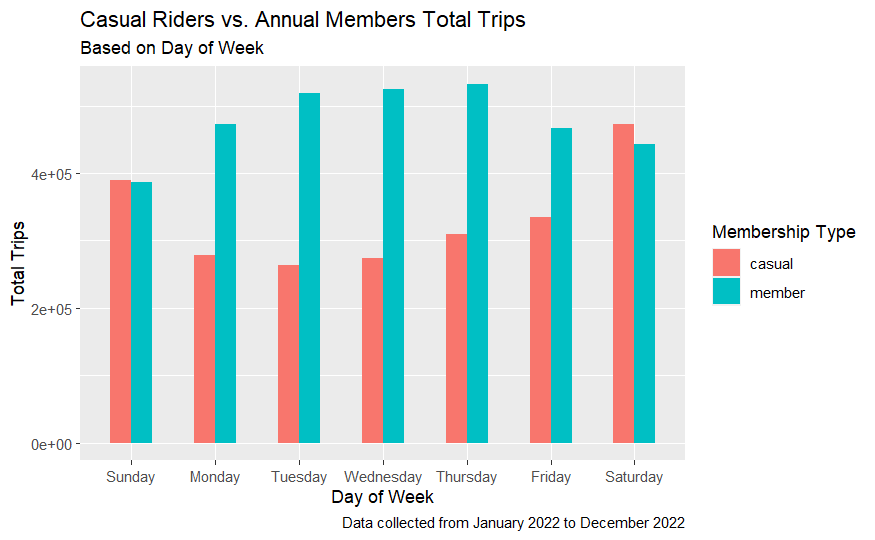

```r
ggplot(query1_df, aes(x = day_of_week, y = total_trips, fill = member_casual)) +
  geom_bar(width=0.5, stat = "identity", position = "dodge") +
  labs(title="Casual Riders vs. Annual Members Total Trips",
       subtitle = "Based on Day of Week",
       caption = "Data collected from January 2022 to December 2022",
       x = "Day of Week",
       y = "Total Trips",
       fill = "Membership Type")
```

The visualization shows that the total number of trips taken by annual members peaks around **Tuesday**, **Wednesday**, and **Thursday**. On those days, however, it is the inverse for casual riders.

2. Query2 Dataframe Visualization:

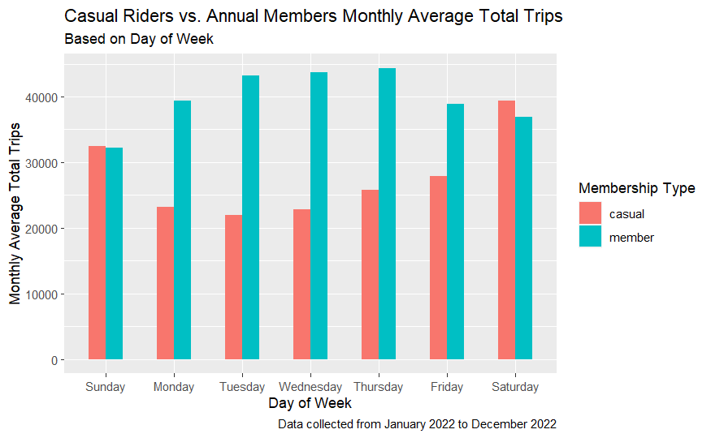

```r
ggplot(query2_df, aes(x = day_of_week, y = monthly_average_total_trips, fill = member_casual)) +
  geom_bar(width=0.5, stat = "identity", position = "dodge") +
  labs(title="Casual Riders vs. Annual Members Monthly Average Total Trips",
       subtitle = "Based on Day of Week",
       caption = "Data collected from January 2022 to December 2022",
       x = "Day of Week",
       y = "Monthly Average Total Trips",
       fill = "Membership Type")
```

The trends and patterns in the resulting bar plot are nearly identical to those in the previous plot. This indicates that the trend is likely to continue throughout the year.

3. Query3 Dataframe Visualization:

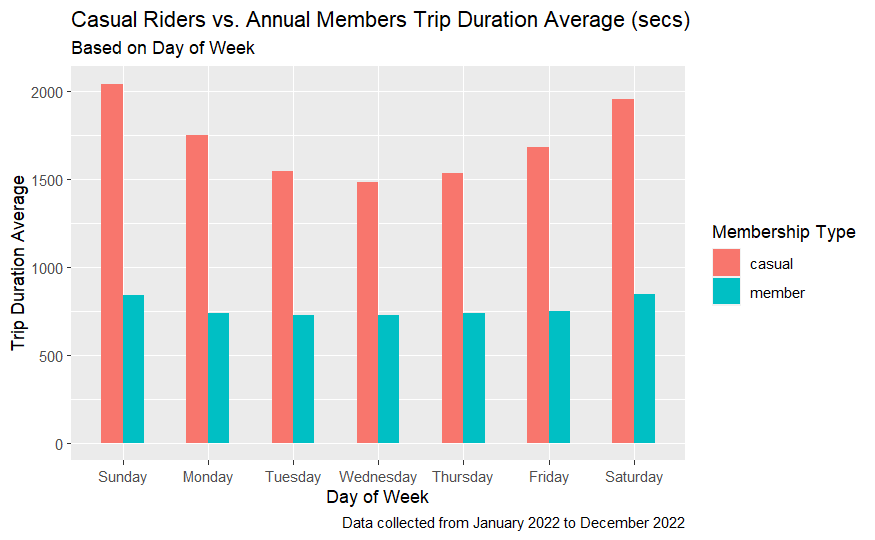

```r
ggplot(query3_df, aes(x = day_of_week, y = day_of_week_trip_duration_average, fill = member_casual)) +
  geom_bar(width=0.5, stat = "identity", position = "dodge") +
  labs(title="Casual Riders vs. Annual Members Trip Duration Average (secs)",
       subtitle = "Based on Day of Week",
       caption = "Data collected from January 2022 to December 2022",
       x = "Day of Week",
       y = "Trip Duration Average",
       fill = "Membership Type")
```

The results show that, while casual riders take fewer trips than annual members, they do have longer average trip durations.

4. Query4 Dataframe Visualization

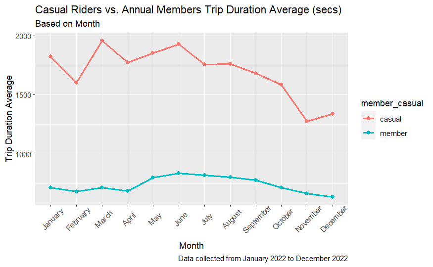

```r
ggplot(query4_df, aes(x=month,
                y=as.numeric(monthly_trip_duration_average),
                group=member_casual, color=member_casual)) +
  geom_line(size=1)+
  geom_point(size=2) +
    labs(title="Casual Riders vs. Annual Members Trip Duration Average (secs)",
       subtitle = "Based on Month",
       caption = "Data collected from January 2022 to December 2022",
       x = "Month",
       y = "Trip Duration Average",
       fill = "Membership Type") +
  theme(axis.text.x = element_text(vjust=0.7, angle=45))
```

The outcome complements the previous visualization’s insight. The casual riders do take longer trips, which peak in **March**.

5. Query5 Dataframe Visualization

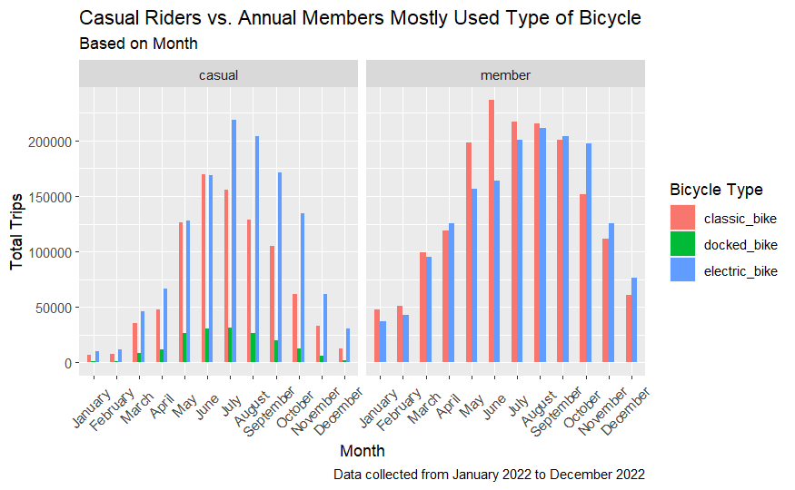

```r
ggplot(query5_df, aes(x = month, y = total_trips, fill = rideable_type)) +
  geom_bar(width=0.5, stat = "identity", position = "dodge") +
  facet_wrap(~member_casual) +
  theme(axis.text.x = element_text(vjust=0.7, hjust=0.7, angle=45)) +
  labs(title="Casual Riders vs. Annual Members Mostly Used Type of Bicycle",
       subtitle = "Based on Month",
       caption = "Data collected from January 2022 to December 2022",
       x = "Month",
       y = "Total Trips",
       fill = "Bicycle Type")
```

The results show that casual riders used electric bikes more frequently, with the month of July being the most popular. We could begin offering annual membership discounts for electric bikes that month in order to entice casual riders to sign up for annual memberships because demand is high that month and in the months following.

6.1. Query6 Dataframe Visualization

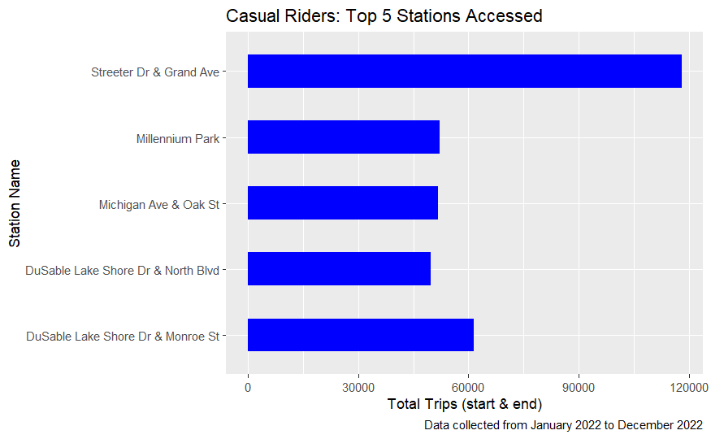

```r
#Since we want to focus on how to efficiently target our ads to casual riders let's filter our query6 dataframe for casual riders and their top 5 mostly accessed stations.
query6_filtered_df <- query6_df %>%
  filter(member_casual == "casual") %>%
  arrange(desc(total_trips)) %>%
  slice(1:5)

ggplot(query6_filtered_df, aes(x = total_trips, y = station_name)) +
  geom_bar(width=0.5, fill="blue", stat="identity") +
  labs(title="Casual Riders: Top 5 Stations Accessed",
       caption = "Data collected from January 2022 to December 2022",
       x = "Total Trips (start & end)",
       y = "Station Name")
```

Let’s try to map this out to see how far/close these stations are. In the *Process* phase, we will use the station_names_geo dataframe that we created earlier.

6.2. Query6 Dataframe Visualization

```r
#Since we want to focus on how to efficiently target our ads to casual riders let's filter our query6 dataframe for casual riders and their top 10 mostly accessed stations.
query6_geomap_df <- merge(query6_filtered_df, station_names_geo_map, by="station_name")

# Create a map centered on Chicago with zoom level 12
station_map_plot <- leaflet() %>% addTiles() %>% setView(lng = -87.6147, lat = 41.8969, zoom = 12)
# Add markers for each point in
station_map_plot %>% addMarkers(data = query6_geomap_df, ~long, ~lat, popup = query6_geomap_df$station_name)
```

[interactive chart not shown]

These stations appear to be close to one another. Creating discounted offers or promotions for newly subscribed annual members who access these stations (start and end) could help entice casual riders to join.

## Act

Here are our main take aways from our overall analysis:

1. *Annual members make a lot of trips on **Tuesdays**, **Wednesdays**, and **Thursdays**. Meanwhile, casual riders make a lot of trips on **Saturdays** and **Sundays**.*
2. *When compared to annual members, casual riders have longer trip durations.*
3. *The average trip duration of casual riders peaks in March.*
4. *Among all types of bicycles, casual riders prefer electric bikes. They use electric bikes the most during the month of July.*
5. *The Top 5 most accessed stations come from casual riders. These stations are also close to each other and near the bay.*

Recommendations based on the analysis:

1. *Offer promotions or discounts to new annual members for 2-3 months during the month of July. Different promotions for electric bike users and those who access the Top 5 stations.*
2. *Create printed ads/promotions for these promotions or discounts in the Top 5 stations.*
3. *Create social media advertisements about the discount/promo offering that target people who work or live near the most frequently accessed stations.*